Dr. Jesús Martí Gavilá. Departamento de Ingeniería Cartográfica, Geodesia y fotogrametría

# PRÁCTICA 10

# EJERCICIO PRÁCTICO CON GOOGLE EARTH ENGINE PARA PYTHON

[figure not shown]

## Grado Tecnologías Interactivas | Tecnologías de la Información Geográfica

## OBJETIVOS

Utilizar la plataforma de Google Earth Engine donde el alumno, de forma autónoma, obtenga los valores del Indice Medioambiental asignado, en función de dos constelaciones de satélites y sea plasmado en una WebMapping

## Resultados:

- Crear un WebMapping con los resultados de los índices cálculados
- Exportar las imágenes en formato Geotiff a Drive, de la zona de estudio

## Librerías y Activación GEE

Cargar las librerías necesarias y activar la plataforma de GEE en la que previamenete el usuario deberá haberse registrado (solo se realiza una única vez por maquina)

```python
!pip install earthengine-api
import folium
from folium import plugins
import ee
import branca
import branca.colormap as cm
ee.Authenticate() #Si ya se está autentificado anteriormente en esta maquina, este paso no es necesario
ee.Initialize()
```

To authorize access needed by Earth Engine, open the following URL in a web browser and follow the instructions:

The authorization workflow will generate a code, which you should paste in the box below.

```
Enter verification code: 4/1AfJohXk3qWeZ0TVEdOVWAUk7mM-Hd8-ZmenffKVNtP513XmbJTkvBe8RZao

Successfully saved authorization token.
```

```python
# Función de GEE predefinida para añadir capas con Folium

def add_ee_layer (self, ee_imagen, parametros, nombre):
    map_id = ee.Image(ee_imagen).getMapId(parametros)
    folium.raster_layers.TileLayer(
        tiles=map_id['tile_fetcher'].url_format,
        attr = 'Diego Baldovi Hugo Martin Tecnologias de la Informacion Geografica', #Indicar el nombre de los componentes del grupo
        name = nombre,
        overlay = True, # Permite la superposición
        control = True # Permite que aparezca la capa o no en el layer control
        ).add_to(self)

# Con esto creamos un método propio llamado addLayer que llamara a la función add_ee_layer
folium.Map.addLayer = add_ee_layer
```

```python
# Leyenda
colormap = cm.StepColormap(['red','yellow','green','blue'], index=[-1,-0.3,0,0.2,1],vmin=-1, vmax=1, max_labels=5,caption='Valores del NDWI y MNDWI',tick_labels=[])

# mapa.add_child(colormap) ............Utilizar esta expresión para añadir la rampa al mapa
colormap
```

[figure not shown]

# Estudio de Indices de AGUA con Google Earth Engine.

## Caso de estudio

#### -------------------------------------------------------------------------------------------------------------------------------------------------------------------------------------------------------------

El método Índice de agua de diferencia normalizada (NDWI, por sus siglas en inglés) es un índice que sirve para definir y monitorizar los cambios de contenido en aguas superficiales.

## TAREA 1

### Calcular el Indice con imágenes satélite de la plataformas correspondiente al grupo asignado

Se calculará el Indice con las imágenes satélite de 2 plataformas para un periodo de tiempo establecido y un lugar de estudio, en función del grupo de estudio asignado.

## Valores rampa de colores

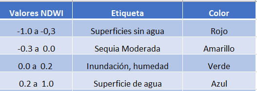

```python
# Colección de imágenes de Sentinel con una nubosidad inferior al 20% y la medía calculada de los pixels
LANDSAT8_2022= (ee.ImageCollection('LANDSAT/LC08/C02/T1_L2')
                  .filterDate('2022-03-21', '2022-06-21')
                  .filter(ee.Filter.lt('CLOUD_COVER',20)).mean()) #el filtro de nubosidad varía según imagen

LANDSAT8_2023= (ee.ImageCollection('LANDSAT/LC08/C02/T1_L2')
                  .filterDate('2023-03-21', '2023-06-21')
                  .filter(ee.Filter.lt('CLOUD_COVER',20)).mean())

LANDSAT9_2022= (ee.ImageCollection('LANDSAT/LC09/C02/T1_L2')
                  .filterDate('2022-03-21', '2022-06-21')
                  .filter(ee.Filter.lt('CLOUD_COVER',20)).mean())

LANDSAT9_2023= (ee.ImageCollection('LANDSAT/LC09/C02/T1_L2')
                  .filterDate('2023-03-21', '2023-06-21')
                  .filter(ee.Filter.lt('CLOUD_COVER',20)).mean())

# Funciones de calculo NBR
def NDWI(image):
    NDWI = image.expression('float(NIR-SWIR)/(NIR+SWIR)',{
        'NIR' : image.select("SR_B5").multiply(0.0000275).add(-0.2),
        'SWIR' : image.select("SR_B6").multiply(0.0000275).add(-0.2),
    })
    return NDWI

sld_intervalos = """
    <RasterSymbolizer>
        <ColorMap type="intervals" extended="false" >
            <ColorMapEntry color="#FF0000" quantity="1" label="Superficie de agua"/>
            <ColorMapEntry color="#ffff00" quantity="0.2" label="Inundacion, Humedad" />
            <ColorMapEntry color="#008f39" quantity="0" label="Sequia moderada" />
            <ColorMapEntry color="#0000ff" quantity="-0.3" label="Superficie sin agua" />
        </ColorMap>
    </RasterSymbolizer>"""

# Llamada a las funciones
landsat8_2022 = NDWI(LANDSAT8_2022)
landsat8_2023 = NDWI(LANDSAT8_2023)
landsat9_2022 = NDWI(LANDSAT9_2022)
landsat9_2023 = NDWI(LANDSAT9_2023)


# Exportar imagen a Google Drive. Configuración parámetros de salida
geometry = ee.Geometry.Rectangle([35.57, 135.76, 34.96, 136.51]) #lat, lng, lat, lng
# Coordenadas geográficas minima y maxima de la imagen a exportar
task_config82022 = {
        'region': geometry,
        'fileFormat': 'GeoTIFF',
        'fileNamePrefix': 'pruebaFoto',
        'folder':'gee-datos',
        'scale': 25000,      # Resolución en metros del pixel
        'crs': 'EPSG:4326',
        'image': landsat8_2022,
        'description': 'Imagen procesada NDWI landsat8 2022'
    }
task_config82023 = {
        'region': geometry,
        'fileFormat': 'GeoTIFF',
        'fileNamePrefix': 'Baldovi_Martin_NDWI_landsat8_2023',
        'folder':'gee-datos',
        'scale': 2600,      # Resolución en metros del pixel
        'crs': 'EPSG:4326',
        'image': landsat8_2023,
        'description': 'Imagen procesada NDWI landsat8 2023'
    }
task_config92022 = {
        'region': geometry,
        'fileFormat': 'GeoTIFF',
        'fileNamePrefix': 'Baldovi_Martin_NDWI_landsat9_2022',
        'folder':'gee-datos',
        'scale': 2600,      # Resolución en metros del pixel
        'crs': 'EPSG:4326',
        'image': landsat9_2022,
        'description': 'Imagen procesada NDWI landsat9 2022'
    }
task_config92023 = {
        'region': geometry,
        'fileFormat': 'GeoTIFF',
        'fileNamePrefix': 'Baldovi_Martin_NDWI_landsat9_2023',
        'folder':'gee-datos',
        'scale': 2600,      # Resolución en metros del pixel
        'crs': 'EPSG:4326',
        'image': landsat9_2022,
        'description': 'Imagen procesada NDWI landsat9 2023'
    }
ee.batch.Export.image.toDrive(**task_config82022).start()
ee.batch.Export.image.toDrive(**task_config82023).start()
ee.batch.Export.image.toDrive(**task_config92022).start()
ee.batch.Export.image.toDrive(**task_config92023).start()

# Crear y añadir elementos al mapa
mapa_NDWI = folium.Map(location=[35.20, 136.06], zoom_start = 10)


mapa_NDWI.addLayer(landsat8_2022.sldStyle(sld_intervalos),None,'landsat8_2022')
mapa_NDWI.addLayer(landsat8_2023.sldStyle(sld_intervalos),None,'landsat8_2023')
mapa_NDWI.addLayer(landsat9_2022.sldStyle(sld_intervalos),None,'landsat9_2022')
mapa_NDWI.addLayer(landsat9_2023.sldStyle(sld_intervalos),None,'landsat9_2023')

folium.LayerControl().add_to(mapa_NDWI)

mapa_NDWI
```

Make this Notebook Trusted to load map: File -> Trust Notebook

[interactive chart not shown]